# A Survey of Red Wine Factors by Tyler Barbian

# Multivariate Plots Section

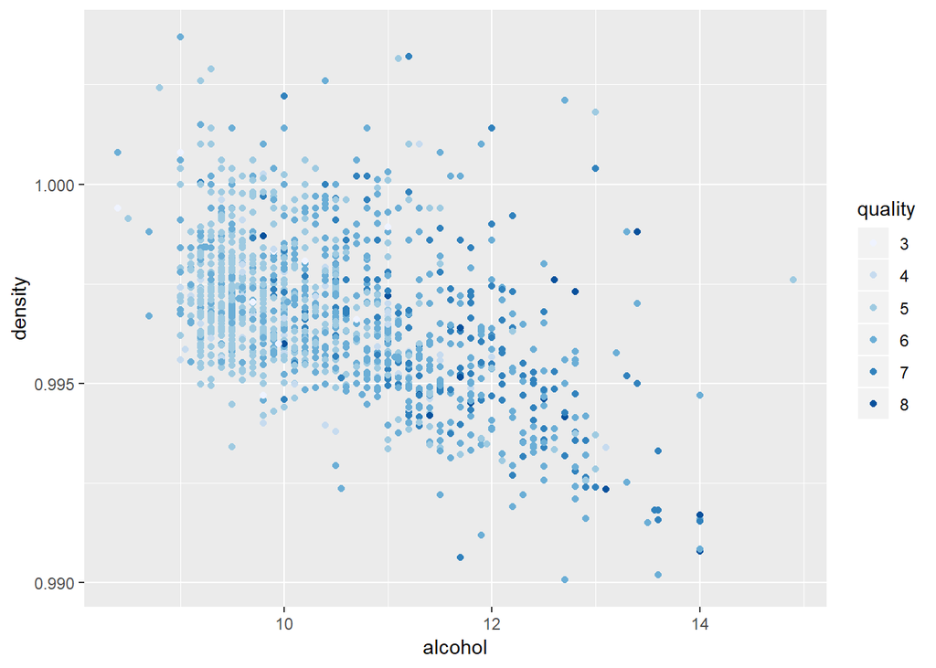

There is a definite trend between density and alcohol, and the higher alcohol higher quality trend is visible as well. It looks like density doesn’t affect quality as much.

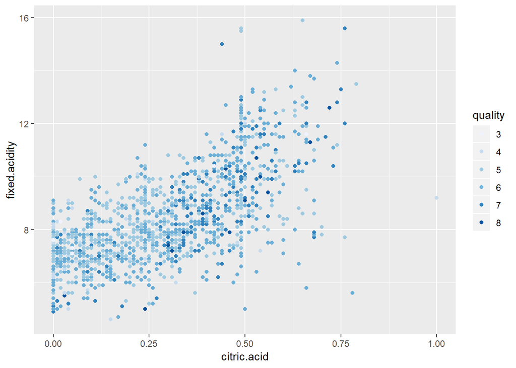

It looks like the higher quality wines have a lower fixed acidity, but higher citirc acid concentrations negate this fact, allowing high fixed acidity to still have high quality as well.

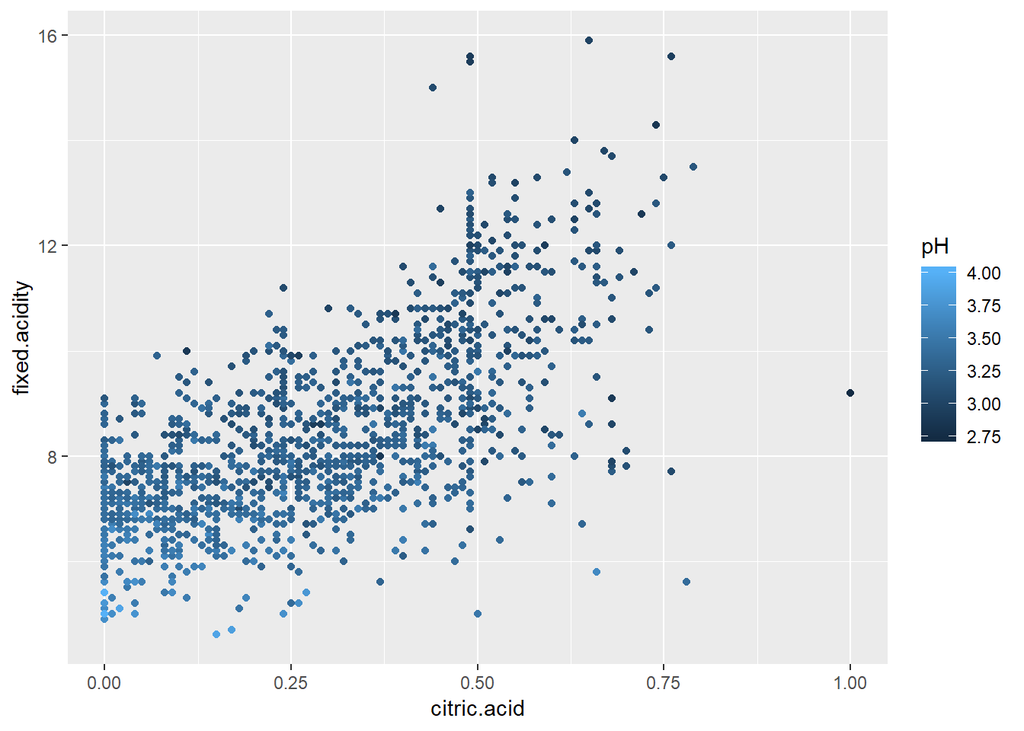

This shows pH changing across acidity concentrations.

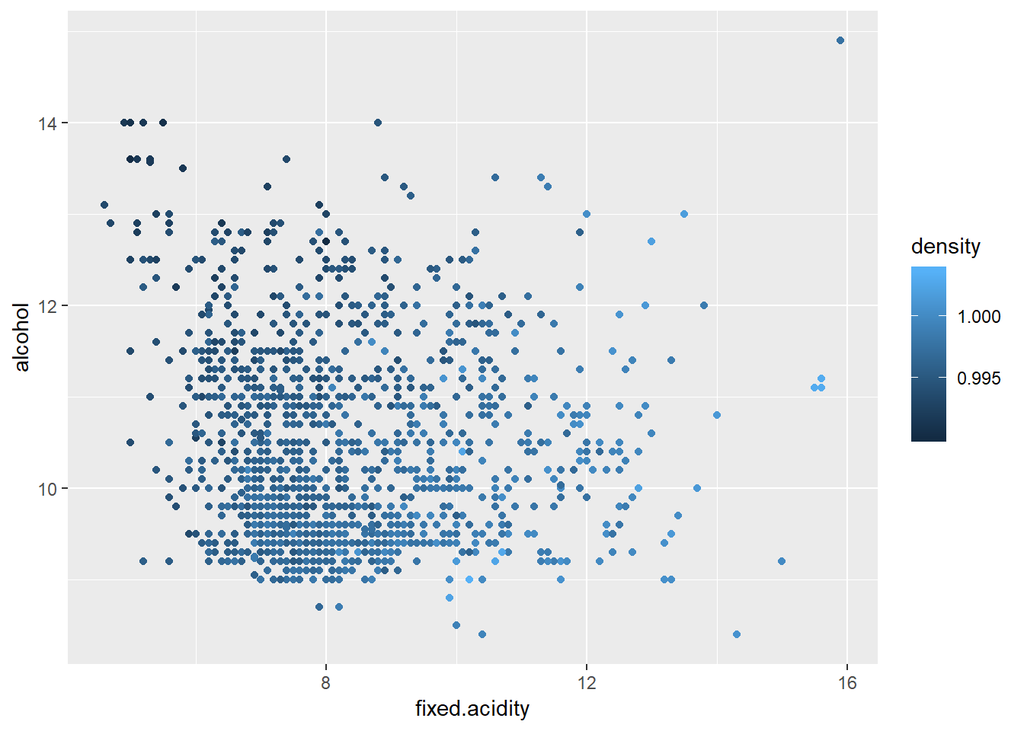

based on the color patterning, it still looks like fixed acidity doesn’t have much relation with alcohol. It does show that the alcohols with a higher density tend to have more fixed acidity as well.

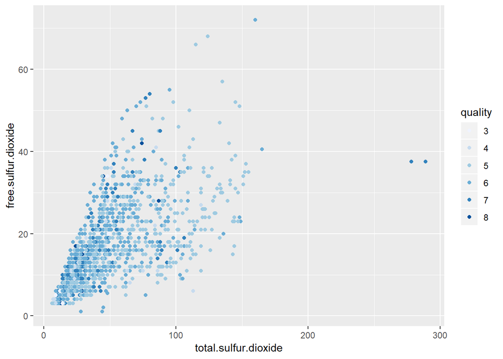

This shows a clear trend between free sulfur dioxide and total sulfur dioxide, but there still doesn’t seem to be much effect on quality.

# Multivariate Analysis

No factors had a strong effect on quality, which was disappointing. All the measures of acidity had strong correlation with each other. This is a confirmation of what I learned in high school chemistry. Increasing acidity decreases pH. I think the most surprising trend is the way alcohol and density interact. Alcohol must be lest dense than water.

### Plot One

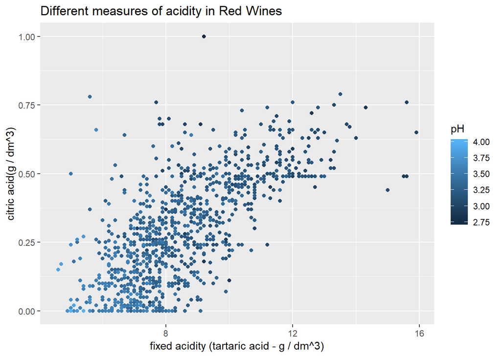

### Description One

This plot shows the positive tren between fixed acidity and citric acid. It is a logical trend, since increasing citric acid would increase the overall fixed acidity in the wine. This is further communicated with the pH coloring. Keep in mind, a lower pH indicates a more acidic substance.

### Plot Two

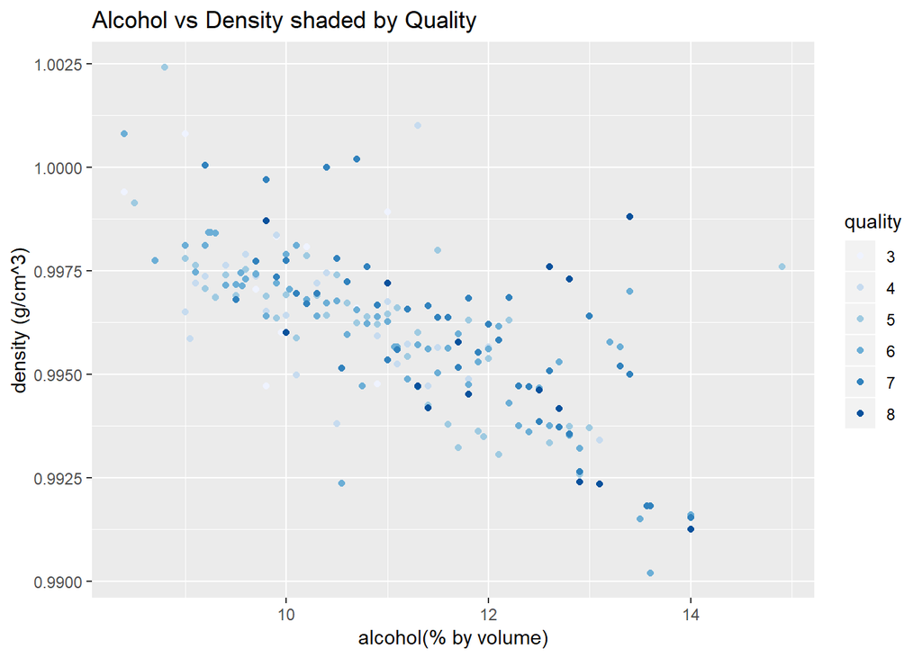

### Description Two

This plot shows the negative correlation between alcohol and density. The color shows the trend of increasing quality as alcohol increases and density decreases.

### Plot Three

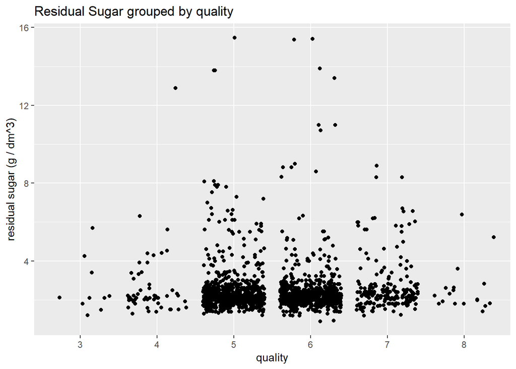

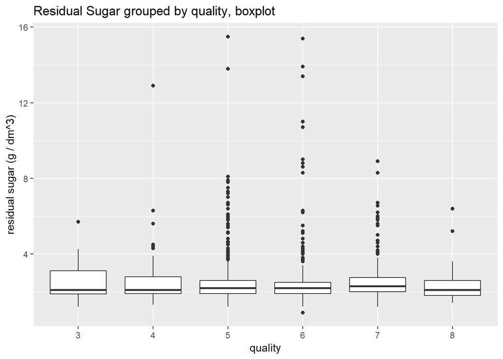

### Description Three

I like this series of graphs because it shows how misleading an initial graph can be. The first graph gives the impression that quality is normally distributed looking at sugar. The box plot reveals that the averages are generally the same, with more outliers in the middle of the graph.

# Reflection

Red Wines aren’t as simple as I hoped. There wasn’t really a clear correlation between quality and any of the other variables. The strongest trend was high quality wines have more alcohol and more citric acid, but those weren’t very conclusive. I think a measure of wine color could be another variable to consider in the future, as something visually pleasing might make the wine more enjoyable over all. Subdividing the wine by type could prove useful as well. Maybe all merlot wines get higher ratings, or have a lower acidity. If I was to design the highest quality wine from this data, it would be very alcoholic, not very dense, and have a healthy amount of citric acid in it.